# Machine Learning Approach to Human Activity Recognition

Matt Moocarme

August 23, 2015

## Introduction

Here I will explore the various activities from data gathered from various activity devices such as *Jawbone Up, Nike Fuelband, and Fitbit*. The goal of this course is to identify the difference between 5 barbell activities, labelled *A, B, C, D, and E*, that were performed by 6 individuals.

First I load the needed libraries and data into the workspace

```r
library(caret)
setwd("~/Documents/Coursera Data Science/Machine Learning/")
training <- read.csv("pml-training.csv", header = TRUE, na.strings = c("NA", ""))
testing <- read.csv("pml-testing.csv", header = TRUE, na.strings = c("NA", ""))
```

Next I check to see if the data is data is clean and complete

```r
nrow(training)
```

```
## [1] 19622
```

```r
csums <- colSums(is.na(training));head(csums, n = 20)
```

```
##                    X            user_name raw_timestamp_part_1
##                    0                    0                    0
## raw_timestamp_part_2       cvtd_timestamp           new_window
##                    0                    0                    0
##           num_window            roll_belt           pitch_belt
##                    0                    0                    0
##             yaw_belt     total_accel_belt   kurtosis_roll_belt
##                    0                    0                19216
##  kurtosis_picth_belt    kurtosis_yaw_belt   skewness_roll_belt
##                19216                19216                19216
## skewness_roll_belt.1    skewness_yaw_belt        max_roll_belt
##                19216                19216                19216
##       max_picth_belt         max_yaw_belt
##                19216                19216
```

We can see from the first 20 variables of the data that many of the columns contain almost all *NAs*, and many contain no *NAs*. Columns containing *NA* values will mess with the machine learning algorithm so we will only take columns with no *NA* values. I will also take a look at the column name to see if there are any variables not useful for the identity of the the particular activity

```r
training2 <- training[, (colSums(is.na(training)) == 0)]
testing2 <-testing[, (colSums(is.na(training)) == 0)]
colnames(training2)
```

```
##  [1] "X"                    "user_name"            "raw_timestamp_part_1"
##  [4] "raw_timestamp_part_2" "cvtd_timestamp"       "new_window"
##  [7] "num_window"           "roll_belt"            "pitch_belt"
## [10] "yaw_belt"             "total_accel_belt"     "gyros_belt_x"
## [13] "gyros_belt_y"         "gyros_belt_z"         "accel_belt_x"
## [16] "accel_belt_y"         "accel_belt_z"         "magnet_belt_x"
## [19] "magnet_belt_y"        "magnet_belt_z"        "roll_arm"
## [22] "pitch_arm"            "yaw_arm"              "total_accel_arm"
## [25] "gyros_arm_x"          "gyros_arm_y"          "gyros_arm_z"
## [28] "accel_arm_x"          "accel_arm_y"          "accel_arm_z"
## [31] "magnet_arm_x"         "magnet_arm_y"         "magnet_arm_z"
## [34] "roll_dumbbell"        "pitch_dumbbell"       "yaw_dumbbell"
## [37] "total_accel_dumbbell" "gyros_dumbbell_x"     "gyros_dumbbell_y"
## [40] "gyros_dumbbell_z"     "accel_dumbbell_x"     "accel_dumbbell_y"
## [43] "accel_dumbbell_z"     "magnet_dumbbell_x"    "magnet_dumbbell_y"
## [46] "magnet_dumbbell_z"    "roll_forearm"         "pitch_forearm"
## [49] "yaw_forearm"          "total_accel_forearm"  "gyros_forearm_x"
## [52] "gyros_forearm_y"      "gyros_forearm_z"      "accel_forearm_x"
## [55] "accel_forearm_y"      "accel_forearm_z"      "magnet_forearm_x"
## [58] "magnet_forearm_y"     "magnet_forearm_z"     "classe"
```

From the column names it seems that the variables *X, timestamp, new_window,* and variables containing the term *timestamp* are unrelated to activity so I will nnot nclude them in the algorithm.

```r
del_cols_log <- grepl("X|user_name|timestamp|new_window", colnames(training2))
training2 <- training2[, !del_cols_log]
testing2 <- testing2[, !del_cols_log]
```

Next I will partition the training set into a dataset to train on and one to validate on

```r
inTrain = createDataPartition(y = training2$classe, p = 0.7, list = FALSE)
training3 = training2[inTrain, ]
XvalidSet = training2[-inTrain, ]
```

Using the training set I preprocess the datset to include principle component analysis

```r
preProcTraining <- preProcess(training3[, -54], method = "pca", thresh = 0.99)
trainP <- predict(preProcTraining, training3[, -54])
```

I use the random forest algorithm to try and predict the data

```r
set.seed(123)
modelFit <- train(training3$classe ~ ., method = "rf", data = trainP, trControl = trainControl(method = "oob", number = 4), importance = TRUE)
```

I perform an error analysis on the fitting model

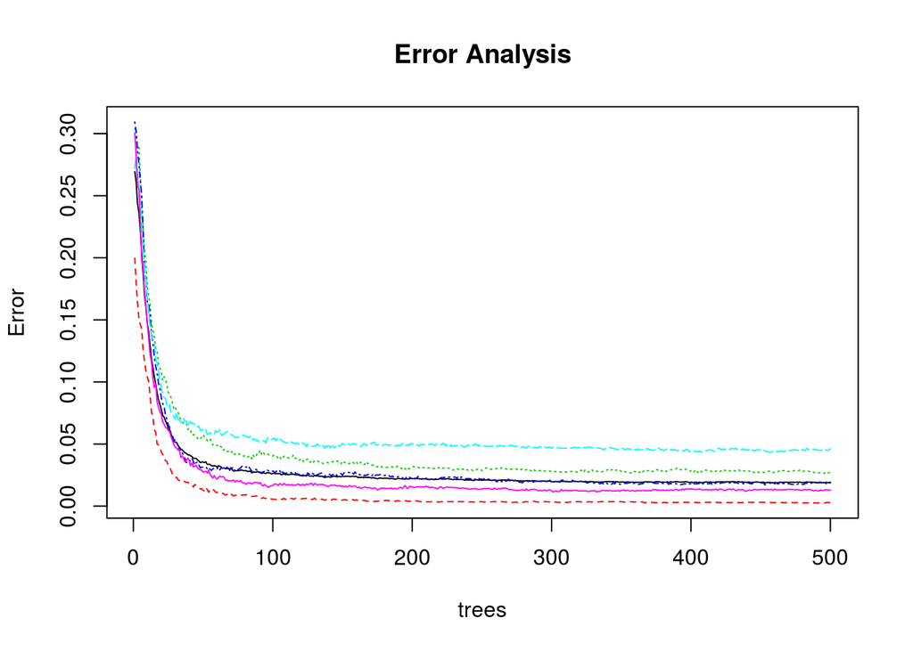

```r
plot(modelFit$finalModel, main = "Error Analysis")
```

Running a confusion matrix on the trainign set should show if we are on the right track

```r
trainCheck <- predict(modelFit, trainP)
confusionMatrix(training3$classe, trainCheck)
```

```
## Confusion Matrix and Statistics
##
##           Reference
## Prediction    A    B    C    D    E
##          A 3906    0    0    0    0
##          B    0 2658    0    0    0
##          C    0    0 2396    0    0
##          D    0    0    0 2252    0
##          E    0    0    0    0 2525
##
## Overall Statistics
##
##                Accuracy : 1
##                  95% CI : (0.9997, 1)
##     No Information Rate : 0.2843
##     P-Value [Acc > NIR] : < 2.2e-16
##
##                   Kappa : 1
##  Mcnemar's Test P-Value : NA
##
## Statistics by Class:
##
##                      Class: A Class: B Class: C Class: D Class: E
## Sensitivity            1.0000   1.0000   1.0000   1.0000   1.0000
## Specificity            1.0000   1.0000   1.0000   1.0000   1.0000
## Pos Pred Value         1.0000   1.0000   1.0000   1.0000   1.0000
## Neg Pred Value         1.0000   1.0000   1.0000   1.0000   1.0000
## Prevalence             0.2843   0.1935   0.1744   0.1639   0.1838
## Detection Rate         0.2843   0.1935   0.1744   0.1639   0.1838
## Detection Prevalence   0.2843   0.1935   0.1744   0.1639   0.1838
## Balanced Accuracy      1.0000   1.0000   1.0000   1.0000   1.0000
```

It is 100% accurate so that is a reassuring sign. Next we perform the test on the cross-validation dataset.

```r
validProc <- preProcess(XvalidSet[,-54], method= "pca", thresh = 0.99)
XvalidSetPC<- predict(validProc, XvalidSet[,-54])
XvalidCheck <- predict(modelFit, XvalidSetPC)
ConfMat <- confusionMatrix(XvalidSet$classe, XvalidCheck)
ConfMat
```

```
## Confusion Matrix and Statistics
##
##           Reference
## Prediction   A   B   C   D   E
##          A 558 327  80  46 663
##          B 167 352  37 101 482
##          C 268 121 216  50 371
##          D 227 209 198  56 274
##          E 120 230  49  31 652
##
## Overall Statistics
##
##                Accuracy : 0.3116
##                  95% CI : (0.2998, 0.3236)
##     No Information Rate : 0.415
##     P-Value [Acc > NIR] : 1
##
##                   Kappa : 0.1321
##  Mcnemar's Test P-Value : <2e-16
##
## Statistics by Class:
##
##                      Class: A Class: B Class: C Class: D Class: E
## Sensitivity           0.41642  0.28410  0.37241 0.197183   0.2670
## Specificity           0.75446  0.83061  0.84731 0.837886   0.8751
## Pos Pred Value        0.33333  0.30904  0.21053 0.058091   0.6026
## Neg Pred Value        0.81430  0.81311  0.92509 0.953668   0.6273
## Prevalence            0.22770  0.21054  0.09856 0.048258   0.4150
## Detection Rate        0.09482  0.05981  0.03670 0.009516   0.1108
## Detection Prevalence  0.28445  0.19354  0.17434 0.163806   0.1839
## Balanced Accuracy     0.58544  0.55735  0.60986 0.517535   0.5711
```

```r
ose <- 1- ConfMat$overall[[1]]
```

Here I get a model accuracy of 31.16% and a out of sample error of 0.6883602.

The accuracy of this model isn’t particularly great. I believe the reason for this is due to oversampling since the error rate does not decrease much as the number of trees goes past around 100, indicating that these increase in trees do not make the model necessarily better and when the data set is changed, for example in the cross validation the model is inaccurate.

## Prediction Results

The predicted results for the test results are as follows:

```r
testPred <- predict(preProcTraining, testing2[,-54])
testPred2 <- predict(modelFit, testPred)
testPred2
```

```
##  [1] B A B A A E D B A A B C B A E E A B B B
## Levels: A B C D E
```